# Exploratory_Analysis_Info201

Bella, Lauren, Tiffany, Junna

11/15/2021

## Introduction

Our group chose mental health as our domain of interest because we are college students and we care about how mental health problems can cause results such as suicide; especially since it is so relevant in our age gorup. From the three datasets we found, we chose the dataset related to the suicide rates from 1985 to 2015. It can be used to compare the suicide numbers between different age groups and sexes and can even track the suicide numbers’ changes over years. Our group’s main focus on this dataset is to compare the difference in suicide rates in two countries, the United State and Japan. In this way, we will be able to know which country has the highest mental health problems according to suicide rates.

## Table of Aggregate Information

```
##           country year    sex         age the number of suicide population
## 1           Japan 1985   male   75+ years                  1340    1791000
## 2           Japan 1985 female   75+ years                  1553    2862400
## 3           Japan 1985   male 55-74 years                  3763    8996900
## 4           Japan 1985   male 35-54 years                  6962   17833300
## 5           Japan 1985   male 25-34 years                  1982    8465800
## 6           Japan 1985 female 55-74 years                  2543   11024900
## 7           Japan 1985 female 35-54 years                  2582   17953700
## 8           Japan 1985   male 15-24 years                  1139    8728500
## 9           Japan 1985 female 25-34 years                   817    8321600
## 10          Japan 1985 female 15-24 years                   491    8366600
## 11          Japan 1985   male  5-14 years                    59    9423300
## 12          Japan 1985 female  5-14 years                    26    9041200
## 13  United States 1985   male   75+ years                  2177    4064000
## 14  United States 1985   male 55-74 years                  5302   17971000
```

[output cut: 730 more lines]

The reason why our group includes this table is that we want to introduce the summary of data we are going to use in the charts and the main focus of our group. And, we choose six most relevant variables to extract in this table. Some variables in the table are related to the demographic information of people in the United State and Japan. They show information such as which age groups people are in. Plus, there are some information related to the total suicide numbers as well as the total population of each age group from 1985 to 2015 in these two countries. With this table or dataset, we can compare the difference between the suicide numbers between the United State and Japan by different methods and aspects and find new insights from the comparison.

## Stacked Column Chart

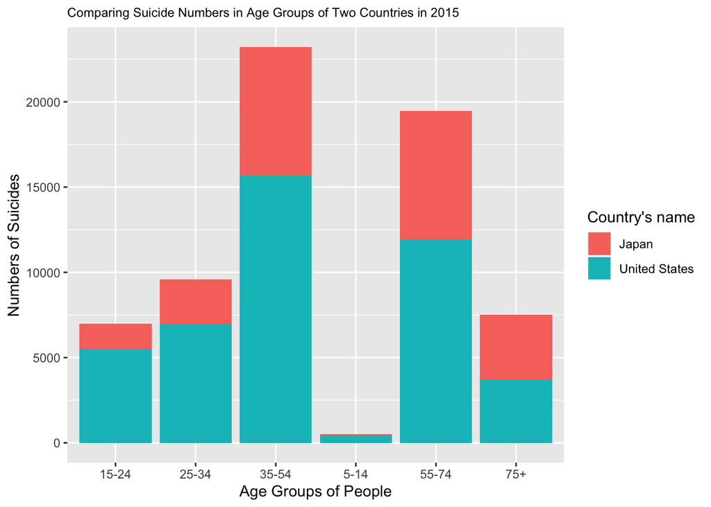

The reason that why our group include this chart is that we want to compare the suicide number in different age groups of the United State and Japan in 2015. We choose the stacked column chart because it can better compare the number of suicide in different age groups as well as in different countries. From the chart, we find that the age group between 35-54 years get the highest number of suicide and the second highest age group is between 55-74 years in both countries. Based on this finding, we can suggest that the age group from 35 to 74 years in United State and Japan get the most pressure and worries. And, the possible reasons behind this are the housing loan and the daily consumption of family members.

## Pie Chart

This pie chart shows the suicide number of different sexes from 5 years old to 75+ years old in the United States in 2015.

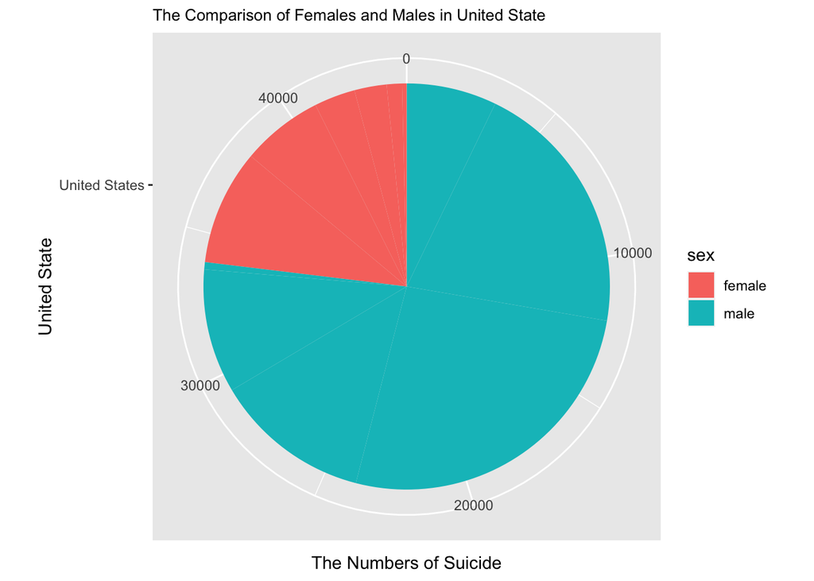

This pie chart shows the suicide number of different sexes from 5 years old to 75+ years old in the Japan in 2015.

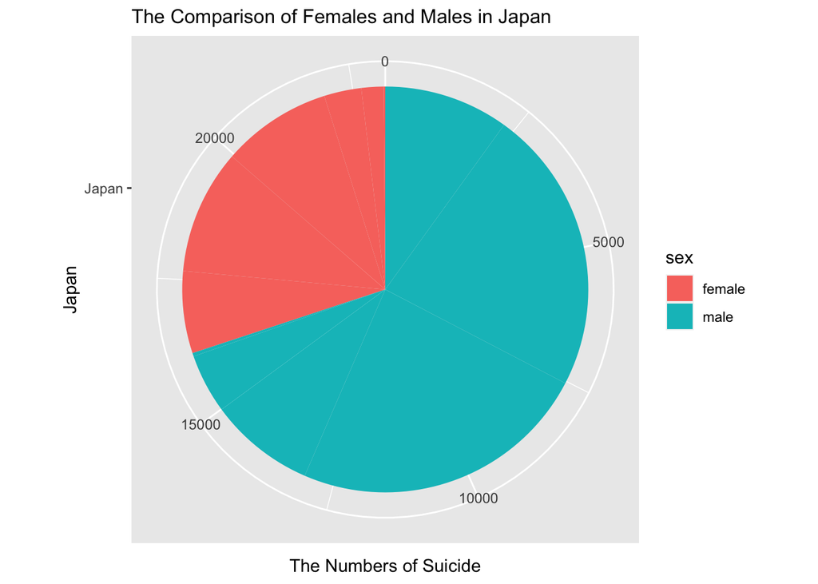

## Line Chart

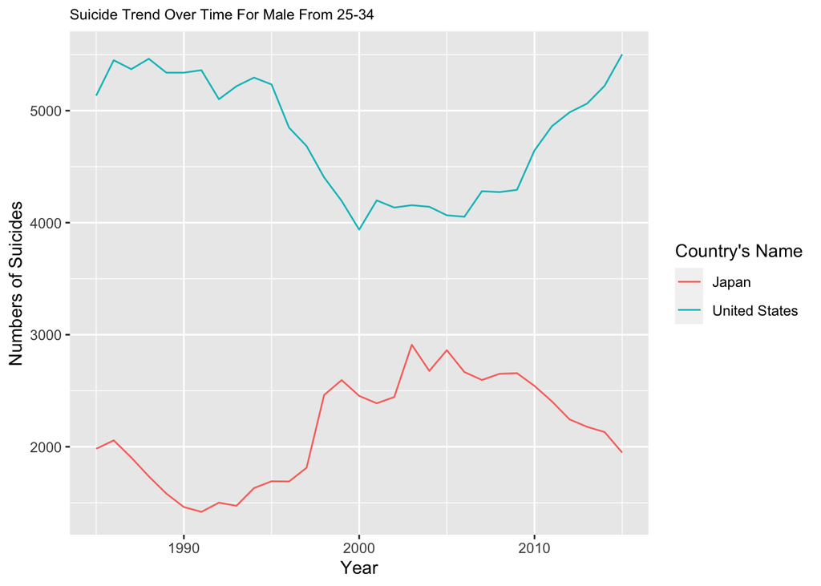

The reason our group chose to make a line chart comparing the number of suicides in males aged 25-34 is because suicide rates are higher in males than females, and we wished to target young adults. From this line chart, our group learned that the United States has had a higher number of suicides based on numbers alone for while. This wasn’t a total surprise - the U.S. has a larger population than Japan. However, something our group did find interesting was the difference in trends between the United States and Japan. For instance, around the year 1995, the United States sees a sharp decrease in suicide numbers while Japan’s increases quite drastically. This opposite reflection continues in 2010 when U.S. suicide numbers increase while Japan’s steadily decline. Without conducting outside research, it’s hard to tell why suicide numbers in Japan reflect the opposite of what they are in the U.S., but it is interesting nonetheless.